# 657a-as1-ques1

```python
import pandas as pd
import seaborn as sns
import matplotlib.pyplot as plt
import warnings
df = pd.read_csv("D:/UWaterloo/Data Knowledge and Modelling/Assignment 1/abalone.csv", names = ['Sex', 'Length', 'Diameter', 'Height', 'Whole_weight',
                      'Sucked_weight', 'Viscera_weight', 'Shell_weight', 'Rings'], sep = ',')
warnings.filterwarnings('ignore')
```

```python
df.head()
```

|  | Sex | Length | Diameter | Height | Whole_weight | Sucked_weight | Viscera_weight | Shell_weight | Rings |
| --- | --- | --- | --- | --- | --- | --- | --- | --- | --- |
| 0 | M | 0.455 | 0.365 | 0.095 | 0.5140 | 0.2245 | 0.1010 | 0.150 | 15 |
| 1 | M | 0.350 | 0.265 | 0.090 | 0.2255 | 0.0995 | 0.0485 | 0.070 | 7 |
| 2 | F | 0.530 | 0.420 | 0.135 | 0.6770 | 0.2565 | 0.1415 | 0.210 | 9 |
| 3 | M | 0.440 | 0.365 | 0.125 | 0.5160 | 0.2155 | 0.1140 | 0.155 | 10 |
| 4 | I | 0.330 | 0.255 | 0.080 | 0.2050 | 0.0895 | 0.0395 | 0.055 | 7 |

```python
df.isna().any()
```

```
Sex               False
Length            False
Diameter          False
Height            False
Whole_weight      False
Sucked_weight     False
Viscera_weight    False
Shell_weight      False
Rings             False
dtype: bool
```

There is no missing data in any of the feature columns. Sex is the only categorical data, with the rest of the features being numerical.

```python
len(df)
```

```
4177
```

```python
df.columns
```

```
Index(['Sex', 'Length', 'Diameter', 'Height', 'Whole_weight', 'Sucked_weight',
       'Viscera_weight', 'Shell_weight', 'Rings'],
      dtype='object')
```

```python
df.describe()
```

|  | Length | Diameter | Height | Whole_weight | Sucked_weight | Viscera_weight | Shell_weight | Rings |
| --- | --- | --- | --- | --- | --- | --- | --- | --- |
| count | 4177.000000 | 4177.000000 | 4177.000000 | 4177.000000 | 4177.000000 | 4177.000000 | 4177.000000 | 4177.000000 |
| mean | 0.523992 | 0.407881 | 0.139516 | 0.828742 | 0.359367 | 0.180594 | 0.238831 | 9.933684 |
| std | 0.120093 | 0.099240 | 0.041827 | 0.490389 | 0.221963 | 0.109614 | 0.139203 | 3.224169 |
| min | 0.075000 | 0.055000 | 0.000000 | 0.002000 | 0.001000 | 0.000500 | 0.001500 | 1.000000 |
| 25% | 0.450000 | 0.350000 | 0.115000 | 0.441500 | 0.186000 | 0.093500 | 0.130000 | 8.000000 |
| 50% | 0.545000 | 0.425000 | 0.140000 | 0.799500 | 0.336000 | 0.171000 | 0.234000 | 9.000000 |
| 75% | 0.615000 | 0.480000 | 0.165000 | 1.153000 | 0.502000 | 0.253000 | 0.329000 | 11.000000 |
| max | 0.815000 | 0.650000 | 1.130000 | 2.825500 | 1.488000 | 0.760000 | 1.005000 | 29.000000 |

```python
df.info()
```

```
<class 'pandas.core.frame.DataFrame'>
RangeIndex: 4177 entries, 0 to 4176
Data columns (total 9 columns):
 #   Column          Non-Null Count  Dtype
---  ------          --------------  -----
 0   Sex             4177 non-null   object
 1   Length          4177 non-null   float64
 2   Diameter        4177 non-null   float64
 3   Height          4177 non-null   float64
 4   Whole_weight    4177 non-null   float64
 5   Sucked_weight   4177 non-null   float64
 6   Viscera_weight  4177 non-null   float64
 7   Shell_weight    4177 non-null   float64
 8   Rings           4177 non-null   int64
dtypes: float64(7), int64(1), object(1)
memory usage: 293.8+ KB
```

```python
df['Sex'].describe()
```

```
count     4177
unique       3
top          M
freq      1528
Name: Sex, dtype: object
```

```python
df['Sex'].value_counts()
```

```
M    1528
I    1342
F    1307
Name: Sex, dtype: int64
```

```python
df.median()
```

```
Length            0.5450
Diameter          0.4250
Height            0.1400
Whole_weight      0.7995
Sucked_weight     0.3360
Viscera_weight    0.1710
Shell_weight      0.2340
Rings             9.0000
dtype: float64
```

```python
df.var()
```

```
Length             0.014422
Diameter           0.009849
Height             0.001750
Whole_weight       0.240481
Sucked_weight      0.049268
Viscera_weight     0.012015
Shell_weight       0.019377
Rings             10.395266
dtype: float64
```

```python
df.skew()
```

```
Length           -0.639873
Diameter         -0.609198
Height            3.128817
Whole_weight      0.530959
Sucked_weight     0.719098
Viscera_weight    0.591852
Shell_weight      0.620927
Rings             1.114102
dtype: float64
```

```python
df.kurtosis()
```

```
Length             0.064621
Diameter          -0.045476
Height            76.025509
Whole_weight      -0.023644
Sucked_weight      0.595124
Viscera_weight     0.084012
Shell_weight       0.531926
Rings              2.330687
dtype: float64
```

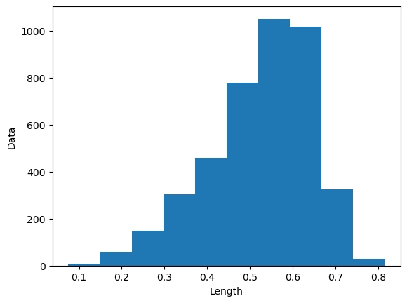

|  | Sex | Length | Diameter | Height | Whole_weight | Sucked_weight | Viscera_weight | Shell_weight | Rings |
| --- | --- | --- | --- | --- | --- | --- | --- | --- | --- |
| 1257 | I | 0.430 | 0.34 | 0.0 | 0.428 | 0.2065 | 0.0860 | 0.1150 | 8 |
| 3996 | I | 0.315 | 0.23 | 0.0 | 0.134 | 0.0575 | 0.0285 | 0.3505 | 6 |

```python
plt.hist(df['Length'], bins=10)
plt.xlabel('Length')
plt.ylabel('Data')
plt.show()
df['Height'].describe()
df[df['Height'] == 0]
```

```python
df[['Whole_weight', 'Sucked_weight', 'Viscera_weight', 'Shell_weight']].describe()
```

|  | Whole_weight | Sucked_weight | Viscera_weight | Shell_weight |
| --- | --- | --- | --- | --- |
| count | 4177.000000 | 4177.000000 | 4177.000000 | 4177.000000 |
| mean | 0.828742 | 0.359367 | 0.180594 | 0.238831 |
| std | 0.490389 | 0.221963 | 0.109614 | 0.139203 |
| min | 0.002000 | 0.001000 | 0.000500 | 0.001500 |
| 25% | 0.441500 | 0.186000 | 0.093500 | 0.130000 |
| 50% | 0.799500 | 0.336000 | 0.171000 | 0.234000 |
| 75% | 1.153000 | 0.502000 | 0.253000 | 0.329000 |
| max | 2.825500 | 1.488000 | 0.760000 | 1.005000 |

1. The number of male fishes is higher than female and infants.
2. For the column of length, the mean is around 0.523 and median is 0.545 (denoted by the 50% value), which shows the distribution must be left skewed due to the presence of infants. The spread is less as SD is less.
3. The min of height feature is 0.000000, which can be an anomaly as other features have valid values. It can be a missing value that needs to be handled. SD is low so the normal distribution is not spread out a lot. It is close to the mean values.
4. Considering the data of all weights in the dataset, they are highly correlated and so we cannot use each weight against another to predict the age of the fish.

Scatter plot : Length vs Whole-weight

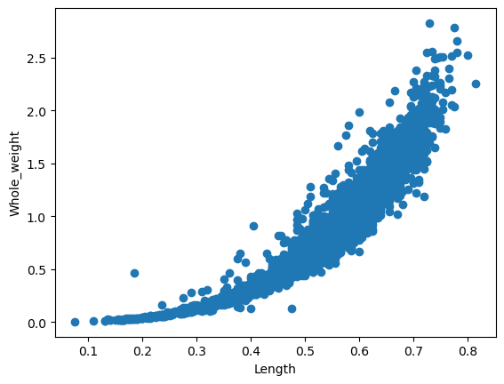

```python
plt.scatter(x=df['Length'], y=df['Whole_weight'])
plt.xlabel('Length')
plt.ylabel('Whole_weight')
```

Height vs Whole weight Analysis: -> There are outliers when height is around 0.5 and height> 1 -> There is more or less a constant relationship between whole_weight and height when height is less than 0.2

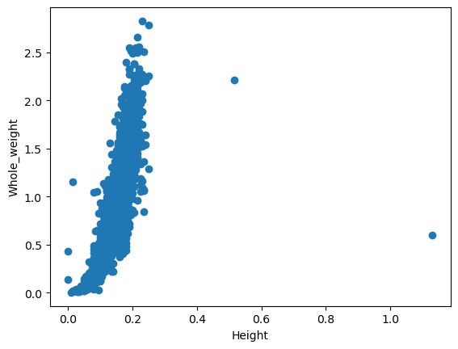

```python
plt.scatter(x=df['Height'], y=df['Whole_weight'])
plt.xlabel('Height')
plt.ylabel('Whole_weight')
```

Diameter vs Whole weight Analysis: -> There are not a lot of outliers and hence this feature can be used to derive a relationship.

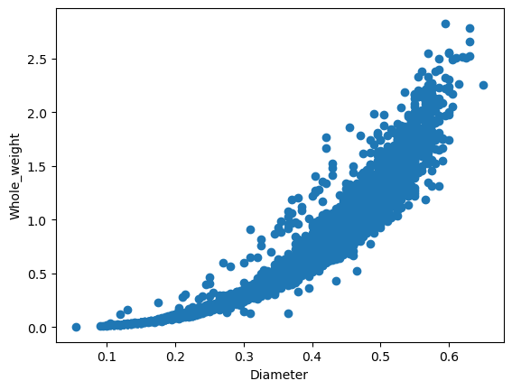

```python
plt.scatter(x=df['Diameter'], y=df['Whole_weight'])
plt.xlabel('Diameter')
plt.ylabel('Whole_weight')
```

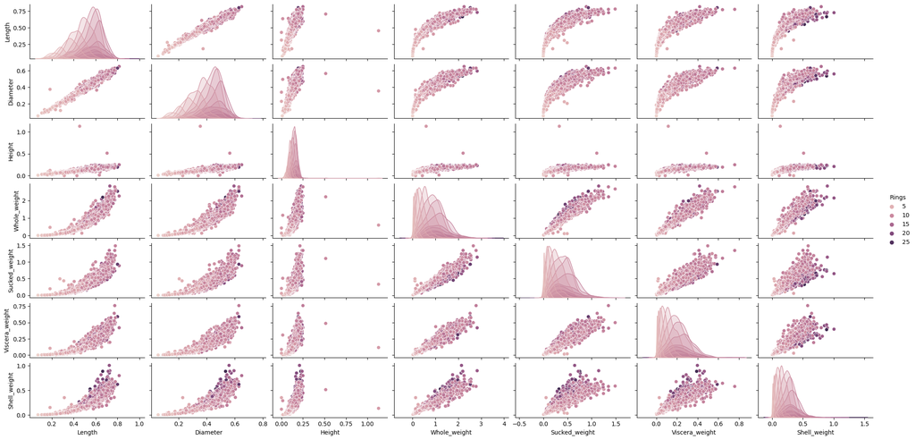

```python
sns.pairplot(df, hue='Rings', height=1.5, aspect=2)
```

```python
df['Rings'].value_counts()
```

```
9     689
10    634
8     568
11    487
7     391
12    267
6     259
13    203
14    126
5     115
15    103
16     67
17     58
4      57
18     42
19     32
20     26
3      15
21     14
23      9
22      6
27      2
24      2
1       1
26      1
29      1
2       1
25      1
Name: Rings, dtype: int64
```

# Splitting the dataset

```python
independent = df.iloc[:, 0:8]
dependent = df.iloc[:, 8]
```

```python
from sklearn.model_selection import train_test_split
ind_train, ind_test, dep_train, dep_test = train_test_split(independent, dependent, test_size = 0.2, random_state=1)

# Balance the training dataset
from imblearn.over_sampling import RandomOverSampler
os = RandomOverSampler(random_state=1)
ind_train_sampled, dep_train_sampled = os.fit_resample(ind_train, dep_train)
```

```python
ind_train_sampled.shape, dep_train_sampled.shape
```

```
((15039, 8), (15039,))
```

```python
print(f"The sampled training dataset is: {dep_train_sampled.value_counts()}")
print(f"The original training dataset is: {dep_train.value_counts()}")
```

```
The sampled training dataset is: 11    557
16    557
26    557
29    557
1     557
27    557
25    557
22    557
18    557
3     557
5     557
14    557
6     557
21    557
4     557
```

[output cut: 41 more lines]

# Apply Z-Score normalization on the sampled dataset

```python
from sklearn.preprocessing import StandardScaler
sc = StandardScaler()
```

```python
ind_train_sampled.iloc[:, 1:] = sc.fit_transform(ind_train_sampled.iloc[:, 1:])
```

```python
ind_train_sampled, dep_train_sampled
```

```
(      Sex    Length  Diameter    Height  Whole_weight  Sucked_weight  \
 0       M -0.403965 -0.443999 -0.489373     -0.796526      -0.791146
 1       I -1.578054 -1.544685 -1.612751     -1.459856      -1.436658
 2       I -0.022386 -0.017927 -0.662201     -0.740038      -0.643479
 3       I  0.564658  0.408146  0.115523     -0.017800       0.329009
 4       I  0.535306  0.550170  0.115523      0.018514       0.191890
 ...    ..       ...       ...       ...           ...            ...
 15034   F  1.034294  1.224784  0.634005      1.340332       1.419630
 15035   F  1.034294  1.224784  0.634005      1.340332       1.419630
 15036   F  1.034294  1.224784  0.634005      1.340332       1.419630
 15037   F  1.034294  1.224784  0.634005      1.340332       1.419630
 15038   F  1.034294  1.224784  0.634005      1.340332       1.419630

        Viscera_weight  Shell_weight
 0           -0.417408     -0.734652
```

[output cut: 24 more lines]